# Composition Analysis of the Czech National Bibliography dated 2025-10-27

# Overall summary

1,263,400 records and 91,747,034 attribute values in total. Constituent files:

- data/cnb/cnb.parquet (257MB)

## Temporal overview

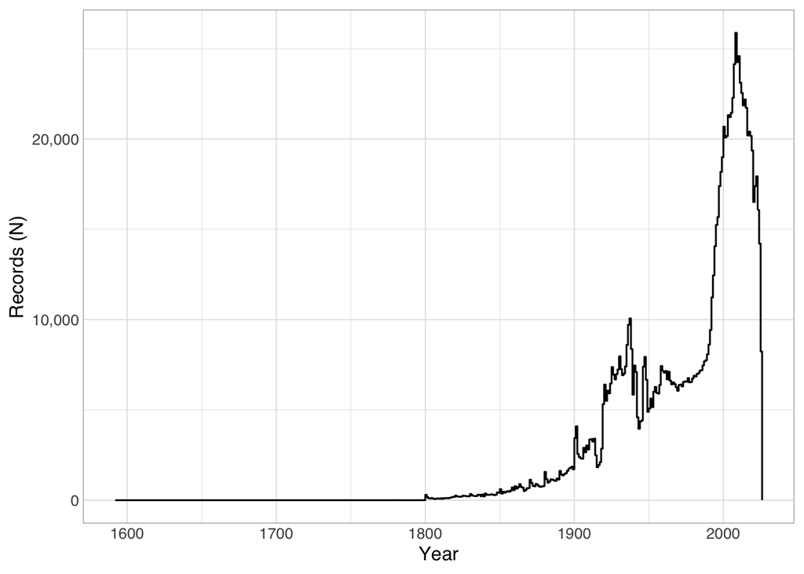

7,722 records do not have easily parseable dates between the years 1000 and 2050.

## Language overview

| [] | Records (N) | Proportion (%) |
| --- | --- | --- |
| cze (Czech) | 1103687 | 0.873584771252177 |
| ger (German) | 49616 | 0.0392718062371379 |
| zxx (No linguistic content; Not applicable) | 31961 | 0.0252976096248219 |
| eng (English) | 30602 | 0.024221940794681 |
| slo (Slovak) | 15417 | 0.0122027861326579 |
|  | 5625 | 0.00445227164793415 |
| rus (Russian) | 5157 | 0.00408184264682602 |
| fre (French) | 5081 | 0.00402168750989394 |
| lat (Latin) | 3086 | 0.00244261516542663 |
| pol (Polish) | 2200 | 0.00174133291119202 |

[output cut: 94 more lines]

# Field code usage overview

In total, 134 distinct fields are used.

Legend for the table below:

- `records`: how many records have at least one of this field
- `r_p`: the above as a percentage of all records
- `n`: the total number of appearances of this field
- `vals_per_rec`: calculated from the above, the mean number of appearances of this field per record
- `recs_with_mult_vals`: the number of records that have more than one repetition of this field

| field_code | field_description | records | r_p | n | vals_per_rec | recs_with_mult_vals |
| --- | --- | --- | --- | --- | --- | --- |
| <a name="001" href="https://www.loc.gov/marc/bibliographic/bd001.html">001</a> | Control Number | 1263400 | 1 | 1263400 | 1 | 0 |
| <a name="003" href="https://www.loc.gov/marc/bibliographic/bd003.html">003</a> | Control Number Identifier | 1263400 | 1 | 1263400 | 1 | 0 |
| <a name="005" href="https://www.loc.gov/marc/bibliographic/bd005.html">005</a> | Date and Time of Latest Transaction | 1258485 | 0.996109703973405 | 1258485 | 1 | 0 |
| <a name="006" href="https://www.loc.gov/marc/bibliographic/bd006.html">006</a> | Additional Material Characteristics | 10964 | 0.00867817001741333 | 10994 | 1.00273622765414 | 30 |
| <a name="007" href="https://www.loc.gov/marc/bibliographic/bd007.html">007</a> | Physical Description | 939724 | 0.743805603925914 | 940105 | 1.00040543819249 | 374 |
| <a name="008" href="https://www.loc.gov/marc/bibliographic/bd008.html">008</a> | General Information | 1263400 | 1 | 1263400 | 1 | 0 |
| <a name="010" href="https://www.loc.gov/marc/bibliographic/bd010.html">010</a> | Library of Congress Control Number | 8 | 6.3321196770619e-06 | 8 | 1 | 0 |
| <a name="015" href="https://www.loc.gov/marc/bibliographic/bd015.html">015</a> | National Bibliography Number | 1263400 | 1 | 1338583 | 1.05950846921007 | 42369 |
| <a name="020" href="https://www.loc.gov/marc/bibliographic/bd020.html">020</a> | International Standard Book Number | 752763 | 0.595823175558018 | 1595391 | 2.11938020333093 | 552939 |
| <a name="022" href="https://www.loc.gov/marc/bibliographic/bd022.html">022</a> | International Standard Serial Number | 11752 | 0.00930188380560393 | 12848 | 1.09326072157931 | 1022 |

[output cut: 124 more lines]

# Field code usage overview by subfield

In total, 696 distinct field+subfield combinations are used.

Legend for the table below:

- `records`: how many records have at least one of this field+subfield
- `r_p`: the above as a percentage of all records
- `dist_vals`: the number of different values appearing in this field+subfield
- `e_vals`: at most seven random sample values of this field+subfield
- `n`: the total number of appearances of this field+subfield
- `vals_per_rec`: calculated from the above, the mean number of appearances of this field+subfield per record
- `recs_with_mult_vals`: the number of records that have more than one repetition of this field+subfield

| subfield_code | subfield_description | records | r_p | dist_vals | e_vals | n | vals_per_rec | recs_with_mult_vals |
| --- | --- | --- | --- | --- | --- | --- | --- | --- |
| [001: Control Number](https://www.loc.gov/marc/bibliographic/bd001.html) |  |  |  |  |  |  |  |  |
| 001$ | NA | 1,263,400 | 100% | 1,263,400 | hud00700719 (1)\|bk192604010 (1)\|cpk19970204319 (1)\|nkc20070533573 (1)\|cps20162803824 (1)\|np9543163 (1)\|nkc20122268308 (1) | 1,263,400 | 1 | 0 |
| [003: Control Number Identifier](https://www.loc.gov/marc/bibliographic/bd003.html) |  |  |  |  |  |  |  |  |
| 003$ | NA | 1,263,400 | 100% | 1 | CZ PrNK (1263400) | 1,263,400 | 1 | 0 |
| [005: Date and Time of Latest Transaction](https://www.loc.gov/marc/bibliographic/bd005.html) |  |  |  |  |  |  |  |  |
| 005$ | NA | 1,258,485 | 99.61% | 1,076,803 | 20211215092751.0 (1)\|20130624112239.0 (1)\|20131126155843.0 (1)\|20090921091943.0 (1)\|20100119150747.0 (1)\|20090528111904.0 (1)\|20181121133609.0 (1) | 1,258,485 | 1 | 0 |
| [006: Additional Material Characteristics](https://www.loc.gov/marc/bibliographic/bd006.html) |  |  |  |  |  |  |  |  |
| 006$ | NA | 10,964 | 0.87% | 45 | m fq d (3)\|m q c (6)\|m q d (1850)\|m\|\|\|\|\|\|\|\|d\|\|\|\|\|\|\|\| (4)\|g164 vl (1)\|sar 0 b0 (5)\|m c (50) | 10,994 | 1 | 30 |
| [007: Physical Description](https://www.loc.gov/marc/bibliographic/bd007.html) |  |  |  |  |  |  |  |  |
| 007$ | NA | 939,724 | 74.38% | 366 | ss lsnjlcmmned (8)\|sd bumennmplne (19)\|ka bo (2)\|sd fsngnnnmned (1)\|hd^afb bu (1)\|ta\|\|\|\|\|\|\|\| (1)\|co gg (31) | 940,105 | 1 | 374 |
| [008: General Information](https://www.loc.gov/marc/bibliographic/bd008.html) |  |  |  |  |  |  |  |  |
| 008$ | NA | 1,263,400 | 100% | 759,456 | 201102s2020 xr acf e 000 0acze (1)\|131218s2013 xr a g 000 1 cze (1)\|050623c20039999xr ux fl 0 b2cze (1)\|000819d19021948xr ar 0 b0cze (1)\|000904s1922 xr 000 cze (1)\|080702s1928 xr ger (1)\|190308s… | 1,263,400 | 1 | 0 |
| [010: Library of Congress Control Number](https://www.loc.gov/marc/bibliographic/bd010.html) |  |  |  |  |  |  |  |  |
| 010$a | LC control number | 8 | 0% | 3 | CZ-PeMB (6)\|00437157 (1)\|af 47000710 (1) | 8 | 1 | 0 |
| [015: National Bibliography Number](https://www.loc.gov/marc/bibliographic/bd015.html) |  |  |  |  |  |  |  |  |
| 015$a | National bibliography number | 1,263,399 | 100% | 1,263,399 | cnb000639864 (1)\|cnb001879226 (1)\|cnb002927016 (1)\|cnb002116257 (1)\|cnb000075876 (1)\|cnb002097151 (1)\|cnb000063053 (1) | 1,263,399 | 1 | 0 |
| 015$z | NA | 42,369 | 3.35% | 75,184 | cnb001714867 (1)\|cnb000096807 (1)\|cnb000009406 (1)\|cnb000897330 (1)\|cnb000472566 (1)\|cnb000041916 (1)\|cnb000478926 (1) | 75,184 | 1.77 | 11,194 |
| [020: International Standard Book Number](https://www.loc.gov/marc/bibliographic/bd020.html) |  |  |  |  |  |  |  |  |
| 020$a | International Standard Book Number | 492,709 | 39% | 516,851 | 978-80-7348-845-1 (1)\|80-85771-83-7 (1)\|978-80-7547-330-1 (1)\|978-80-86486-75-8 (1)\|80-7258-052-3 (1)\|80-04-26009-8 (1)\|978-80-906560-8-6 (1) | 519,500 | 1.05 | 19,556 |
| 020$c | Terms of availability | 183,768 | 14.55% | 6,546 | 159,00 (3)\|Kčs 47,50 (pro studenty PeF v Plzni Kčs 23,75) (1)\|Kč 30,00 [2 sv.] (1)\|Kčs 6,80 (váz. Kčs 11,20) (1)\|Kč 18,50 (18)\|Kč 547,00 (4)\|Kč 267,00 (23) | 186,892 | 1.02 | 2,193 |
| 020$q | NA | 740,155 | 58.58% | 10,166 | (Koexistencia ; (1)\|(Univerzita Hradec Králové ; (3)\|(černobílá verze ; (2)\|díl II ; (2)\|(Antonín Matějka - Moto Public ; (2)\|(Rosa-Luxemburg-Stiftung ; (1)\|Vydavatelství 999 ; (1) | 861,702 | 1.16 | 68,845 |
| 020$z | Cancelled/invalid ISBN | 25,517 | 2.02% | 25,183 | 80-01-02669-8 (1)\|80-213-1009-X (1)\|80-7289-112-x (1)\|978-80-7196-260-1 (1)\|978-80-9002954-3-8 (1)\|80-7289-068-9 (1)\|978-80-7106-432-9 (1) | 27,297 | 1.07 | 1,375 |
| [022: International Standard Serial Number](https://www.loc.gov/marc/bibliographic/bd022.html) |  |  |  |  |  |  |  |  |
| 022$Y | NA | 36 | 0% | 2 | 0 (35)\|1 (1) | 36 | 1 | 0 |
| 022$a | International Standard Serial Number | 11,271 | 0.89% | 11,100 | 0232-0967 (1)\|1212-1193 (1)\|1803-6341 (1)\|1802-7660 (1)\|1804-9737 (1)\|1211-9954 (1)\|2464-6598 (1) | 11,274 | 1 | 3 |
| 022$l | NA | 4 | 0% | 4 | 1803-7976 (1)\|1801-4437 (1)\|1803-7968 (1)\|1212-0235 (1) | 4 | 1 | 0 |
| 022$y | Incorrect ISSN | 1,330 | 0.11% | 930 | 1614-36980 (1)\|0231-7788 (1)\|1212-1991 (1)\|1210-8424 (1)\|1801-9773 (1)\|2365-21600 (1)\|0042-4544 (1) | 1,440 | 1.08 | 95 |
| 022$z | Cancelled ISSN | 86 | 0.01% | 91 | 0567-817X (1)\|1803-1803 (1)\|0862-3562 (1)\|0465-4544 (1)\|0506-4430 (1)\|0411-6216 (1)\|0491-9106 (1) | 94 | 1.09 | 7 |
| [024: Other Standard Identifier](https://www.loc.gov/marc/bibliographic/bd024.html) |  |  |  |  |  |  |  |  |
| 024$2 | Source of code or number | 8 | 0% | 1 | ettn (37) | 37 | 4.62 | 7 |

[output cut: 800 more lines]